# Reproducibility

## Data

Data can be found on [osf.io](https://osf.io/c4xq3/).

We split our data from TikTok and Youtube into two datasets.

The first dataset contains summary statistics at the account-level for all accounts producing content on Youtube and Tiktok (i.e. accounts who produced at least one video that appears in our dataset). It includes the following variables:

- n_follower: the number of followers/subscribers
- n_video: the number of videos produced by the account
- mean_play: the average number of plays per video
- median_play: the median number of plays per video
- total_play: the total number of plays
- most_popular: the maximum number of plays gathered by one video
- ratio: total_play/n_follower
- peak_mean_ratio = most_popular/mean_play
- peak_median_ratio = most_popular/median_play
- gini_views: the Gini coefficient of the views representing providing a measure for how equally distributed the views are across all videos produced by an account

The second dataset contains summary statistics on all the commenter accountson Youtube and Tiktok (i.e. accounts who commented at least one political video in our dataset). It includes following variables:

- n_videos: the number of videos produced by an account
- n_comment: the number of comments posted by an account

### Content-producing accounts

```r
dt_h1 <- read_rds("data/dt_h1.rds") %>%
  glimpse
```

```
## Rows: 12,930
## Columns: 12
## $ user_unique_id    <chr> "t_1", "t_2", "t_3", "t_4", "t_5", "t_6", "t_7", "t_…
## $ n_follower        <int> 316, 3184, 333, 583, 9546, 1187, 358, 373600, 1031, …
## $ Platform          <chr> "TikTok", "TikTok", "TikTok", "TikTok", "TikTok", "T…
## $ gini_views        <dbl> 0.3685372, 0.3089238, 0.9233723, 0.5305554, 0.762610…
## $ n_video           <int> 163, 102, 608, 143, 193, 33, 24, 1664, 87, 649, 46, …
## $ mean_play         <dbl> 276.60563, 2956.86735, 458.82072, 529.26573, 9879.22…
## $ median_play       <dbl> 200.0, 2716.5, 21.0, 295.0, 2574.0, 1684.0, 850.0, 1…
## $ total_play        <dbl> 58917, 289773, 278963, 75685, 2953887, 128248, 11808…
## $ most_popular      <dbl> 2004, 15000, 97800, 8949, 325700, 12100, 63600, 4000…
## $ ratio             <dbl> 186.44620, 91.00911, 837.72673, 129.81990, 309.43715…
## $ peak_mean_ratio   <dbl> 7.244972, 5.072936, 213.155150, 16.908331, 32.968187…
## $ peak_median_ratio <dbl> 10.020000, 5.521811, 4657.142857, 30.335593, 126.534…
```

```r
bt_h1 <- 1:500 %>%
  map_dfr(~{
    dt_h1 %>%
      group_by(Platform) %>%
      sample_n(n()*20/100) %>%
      mutate(bt_index = .x) %>%
      ungroup
  })
```

### Commenter accounts

```r
dt_h2 <- read_rds("data/dt_h2.rds") %>%
  glimpse
```

```
## Rows: 774,834
## Columns: 4
## $ user_unique_id <chr> "t_1", "t_2", "t_3", "t_4", "t_5", "t_6", "t_7", "t_8",…
## $ n_videos       <dbl> 405, 131, 4, 2176, 2, 2, 12, 142, 14, 21, 373, 2, 3, 48…
## $ n_comment      <int> 21, 5, 4, 8, NA, 14, NA, NA, 59, NA, NA, NA, 6, 1, 17, …
## $ Platform       <fct> TikTok, TikTok, TikTok, TikTok, TikTok, TikTok, TikTok,…
```

```r
bt_h2 <- 1:500 %>%
  map_dfr(~{
    dt_h2 %>%
      filter(!is.na(n_comment) | Platform == "YouTube") %>%
      group_by(Platform) %>%
      sample_n(n()*20/100) %>%
      mutate(bt_index = .x) %>%
      ungroup
  })
```

## Figure 2 - Higher Views to Followers Ratio on TikTok

### Total number of plays/number of followers

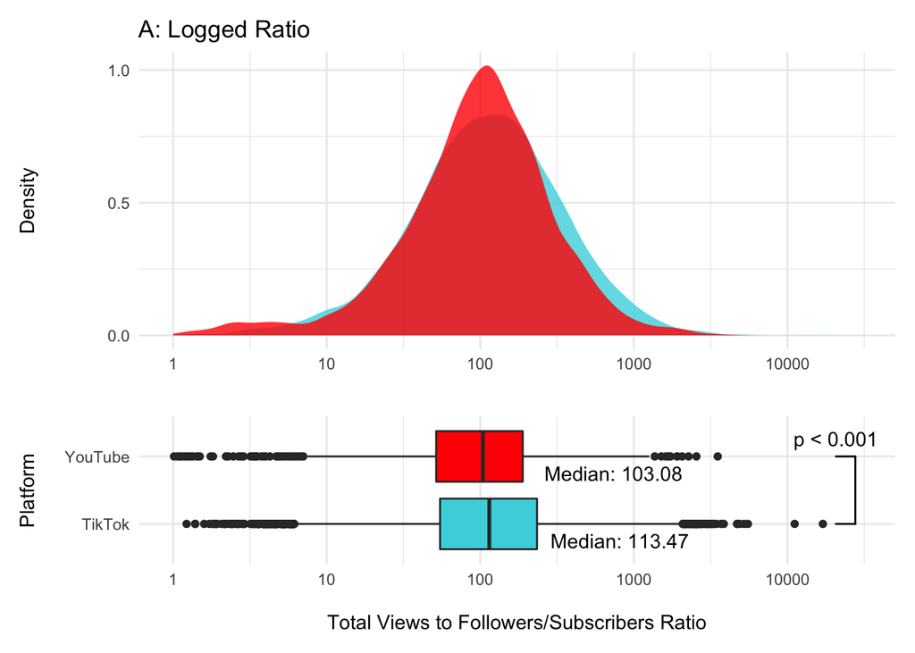

```r
gg_density <- dt_h1 %>%
  ggplot(aes(x = ratio, fill = Platform)) +
  geom_density(color = NA, alpha = 0.8) +
  labs(x = "", y = "Density\n",
       title = "A: Logged Ratio") +
  theme_minimal() +
  scale_y_continuous(n.breaks = 3) +
  theme(legend.position = "none") +
  scale_fill_manual(values = custom_colors) +
  scale_x_log10(limits = c(1, 30000))

w_results <- wilcox.test(ratio ~ Platform, data = dt_h1, paired = F)

median_labs <- dt_h1 %>%
  group_by(Platform) %>%
  summarize(ratio = median(ratio, na.rm = T) %>% round(2)) %>%
  mutate(ratio_label = paste0("Median: ", ratio))

gg_boxplot <- dt_h1 %>%
  ggplot(aes(x= Platform, y = ratio+1, fill = Platform)) +
  geom_boxplot() +
  coord_flip()  +
  labs(x = "Platform\n", y = "\nTotal Views to Followers/Subscribers Ratio") +
  theme_minimal() +
  theme(legend.position = "none")+
  scale_fill_manual(values = custom_colors) +
  geom_signif(comparisons = list(c("YouTube", "TikTok")),
              annotation=get_plabs(w_results$p.value), vjust=-0.65)  +
  geom_text(data = median_labs,aes(label = ratio_label), nudge_x = -0.25, nudge_y = 0.85) +
  scale_y_log10(limits = c(1, 30000))

h1_logged <- wrap_plots(gg_density, gg_boxplot, nrow = 2, heights = c(0.66, 0.33))
h1_logged
```

### Bootstrapped Total number of plays/number of followers

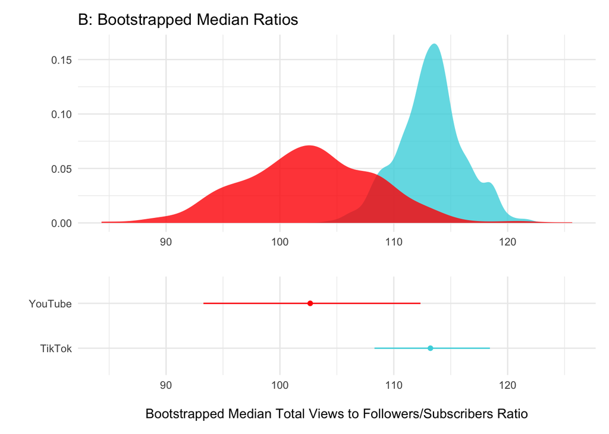

```r
bt_moment <- bt_h1 %>%
  group_by(bt_index, Platform) %>%
  summarize(ratio = median(ratio, na.rm = T) %>% round(2), .groups = "drop") %>%
  group_by(Platform) %>%
  summarise(mean = mean(ratio),
            lbound = quantile(ratio, 5/100),
            hbound = quantile(ratio, 95/100),
            min = min(ratio),
            max = max(ratio))

p1 <- bt_h1 %>%
  group_by(bt_index, Platform) %>%
  summarize(ratio = median(ratio, na.rm = T) %>% round(2)) %>%
  ggplot(aes(x = ratio, fill = Platform)) +
  geom_density(color = NA, alpha = 0.8, show.legend = F) +
  scale_fill_manual(values = custom_colors) +
  theme_minimal() +
  labs(y = "", x = "",
       title = "B: Bootstrapped Median Ratios")

p2 <- bt_moment %>%
  ggplot(aes(x = Platform, color = Platform, y = mean, ymin = lbound, ymax = hbound)) +
  geom_point(show.legend = F) +
  geom_linerange(show.legend = F) +
  scale_color_manual(values = custom_colors) +
  coord_flip() +
  ylim(c(min(bt_moment$min), max(bt_moment$max))) +
  theme_minimal() +
  labs(y = "\nBootstrapped Median Total Views to Followers/Subscribers Ratio", x = "")

h1_bt_view_follower_ratio <- patchwork::wrap_plots(p1, p2, ncol = 1, heights = c(0.66, 0.33))

h1_bt_view_follower_ratio
```

### Combined

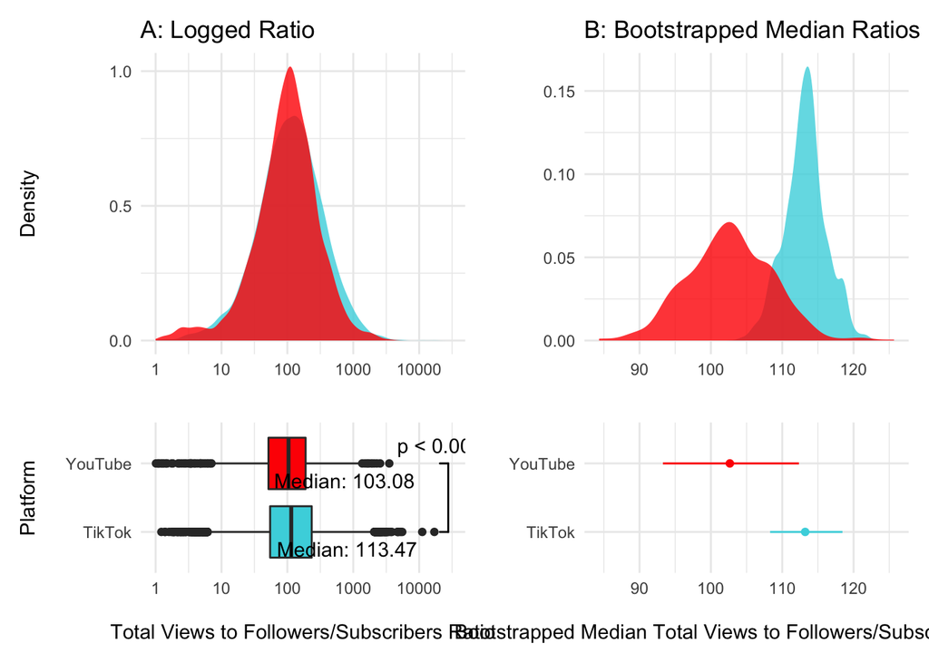

```r
wrap_plots(h1_logged, h1_bt_view_follower_ratio, ncol= 2)
```

## Figure 3 - More commenters also create videos on TikTok

Among accounts that leave comments, the percentage who also upload videos is larger on TikTok than on YouTube

### Number of videos created by commenting account

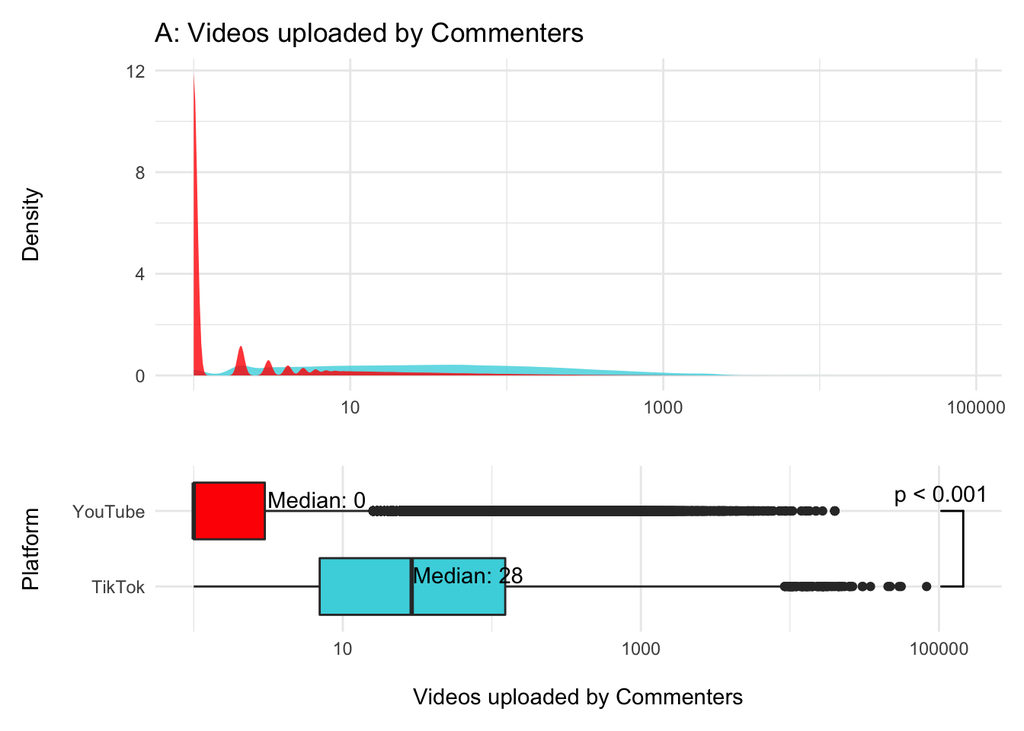

```r
gg_density <- dt_h2 %>%
  mutate(n_videos = ifelse(is.na(n_videos), 0, n_videos + 1)) %>%
  ggplot(aes(x = n_videos, fill = Platform)) +
  geom_density(color = NA, alpha = 0.8) +
  labs(x = "", y = "Density\n",
       title = "A: Videos uploaded by Commenters") +
  theme_minimal() +
  scale_y_continuous(n.breaks = 3) +
  scale_x_log10() +
  theme(legend.position = "none") +
  scale_fill_manual(values = custom_colors)

w_results <- wilcox.test(log(n_videos) ~ Platform, data = dt_h2, paired = F)

median_labs <- dt_h2 %>%
  # filter(n_videos != 0) %>%
  group_by(Platform) %>%
  summarize(n_videos = median(n_videos, na.rm = T) %>% round(2)) %>%
  mutate(ratio_label = paste0("Median: ", n_videos))

gg_boxplot <- dt_h2 %>%
  mutate(n_videos = ifelse(is.na(n_videos), 0, n_videos + 1)) %>%
  ggplot(aes(x= Platform, y = n_videos, fill = Platform)) +
  geom_boxplot() +
  coord_flip()  +
  labs(x = "Platform\n", y = "\nVideos uploaded by Commenters") +
  theme_minimal() +
  theme(legend.position = "none") +
  scale_y_log10() +
  geom_signif(comparisons = list(c("YouTube", "TikTok")),
              annotation=get_plabs(w_results$p.value), vjust=-0.5, test = "wilcox.test", test.args = list(paired = F))  +
  geom_text(data = median_labs,aes(y = n_videos + 3, label = ratio_label), nudge_x = 0.15, nudge_y = 0.35) +
  scale_fill_manual(values = custom_colors)

h2_incl_zero_logged <- wrap_plots(gg_density, gg_boxplot, nrow = 2, heights = c(0.66, 0.33))
h2_incl_zero_logged
```

### Bootstrapped number of videos created by commenting account

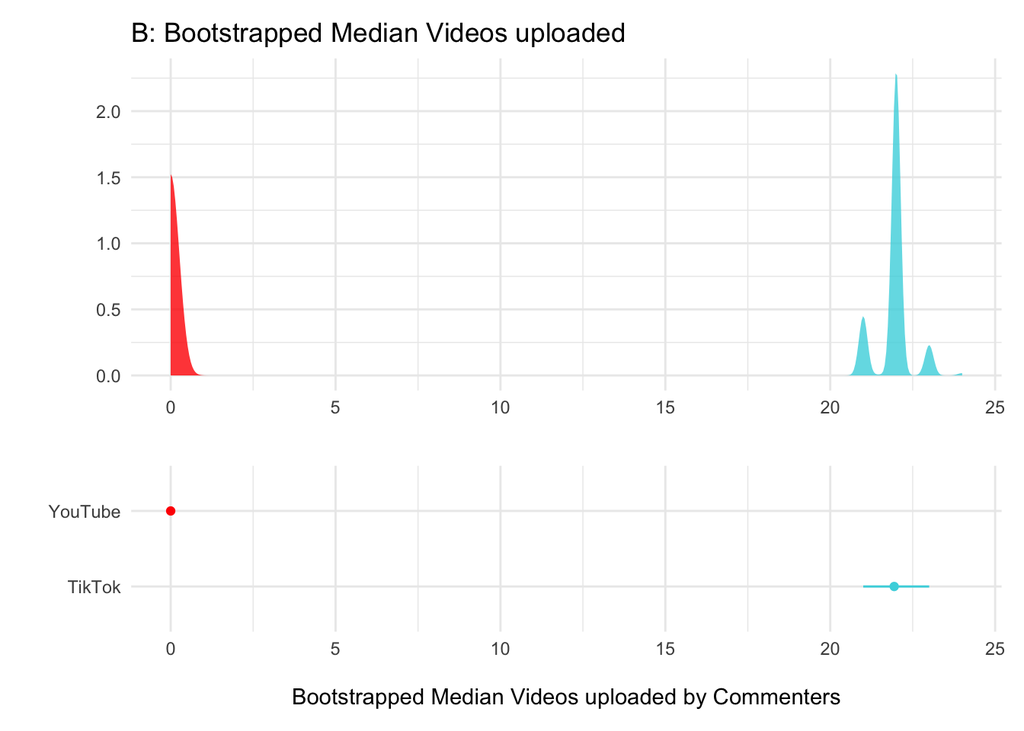

```r
bt_moment <- bt_h2 %>%
  group_by(bt_index, Platform) %>%
  summarize(ratio = median(n_videos, na.rm = T) %>% round(2)) %>%
  group_by(Platform) %>%
  summarise(median = mean(ratio),
            lbound = quantile(ratio, 5/100),
            hbound = quantile(ratio, 95/100),
            min = min(ratio),
            max = max(ratio))

p1 <- bt_h2 %>%
  group_by(bt_index, Platform) %>%
  summarize(ratio = median(n_videos, na.rm = T) %>% round(2)) %>%
  ggplot(aes(x = ratio, fill = Platform)) +
  geom_density(color = NA, alpha = 0.8, show.legend = F) +
  scale_fill_manual(values = custom_colors) +
  theme_minimal() +
  labs(y = "", x = "",
       title = "B: Bootstrapped Median Videos uploaded")

p2 <- bt_moment %>%
  ggplot(aes(x = Platform, color = Platform, y = median, ymin = lbound, ymax = hbound)) +
  geom_point(show.legend = F) +
  geom_linerange(show.legend = F) +
  scale_color_manual(values = custom_colors) +
  coord_flip() +
  ylim(c(min(bt_moment$min), max(bt_moment$max))) +
  theme_minimal() +
  labs(y = "\nBootstrapped Median Videos uploaded by Commenters", x = "")

h2_bt_commenters <- patchwork::wrap_plots(p1, p2, ncol = 1, heights = c(0.66, 0.33))
h2_bt_commenters
```

### Combined

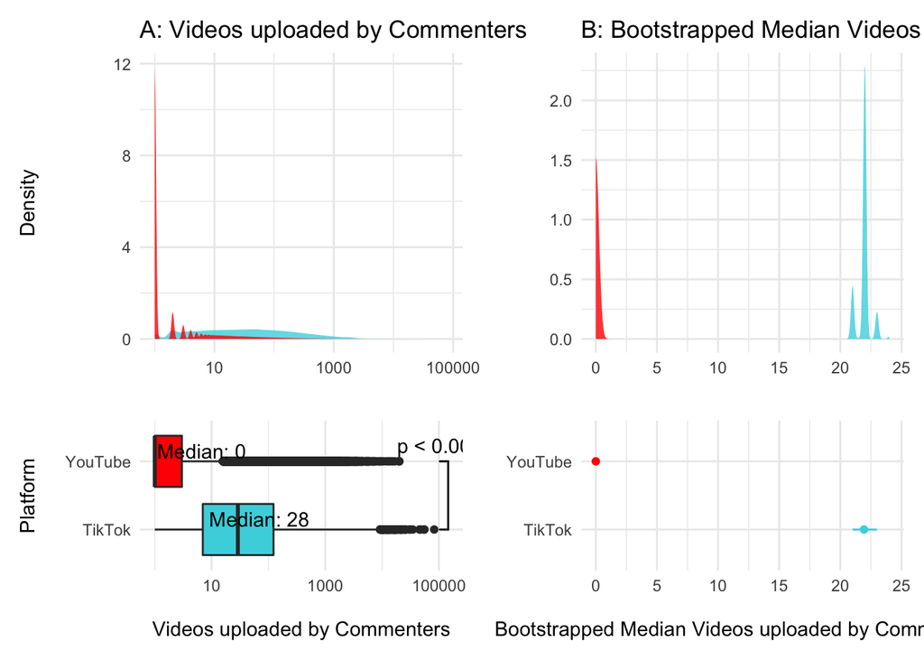

```r
wrap_plots(h2_incl_zero_logged, h2_bt_commenters, ncol= 2)
```

## Figure 4 - Subscriber count explains more of the variance in YouTube Views

The relationship between followers and video views is weaker for TikTok than for YouTube.

### Number of followers/number of plays

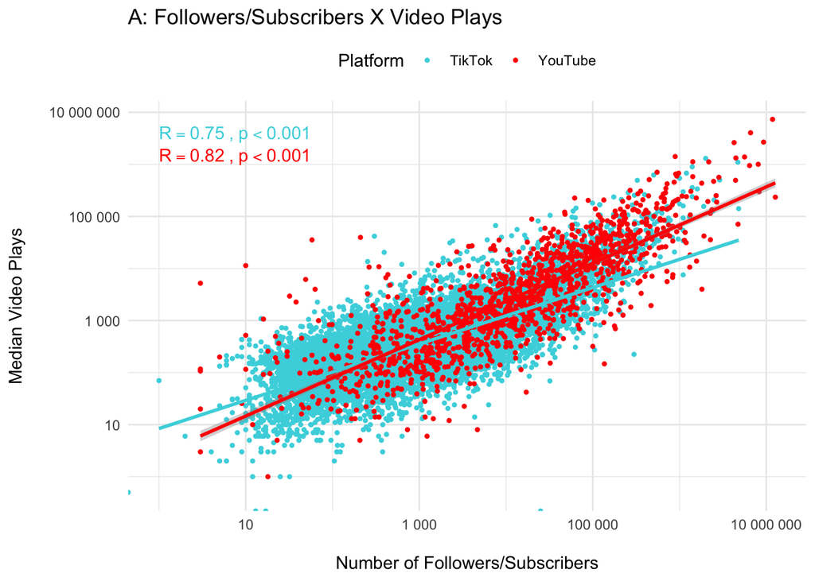

```r
h3_log <- dt_h1 %>%
  ggplot(aes(x = n_follower, y = median_play, color = Platform)) +
  geom_point2() +
  geom_smooth(method = "lm", show.legend = F)  +
  scale_x_log10(labels = scales::label_number(), breaks = scales::breaks_log(6)) +
  scale_y_log10(labels = scales::label_number(), breaks = scales::breaks_log(6)) +
  stat_cor(show.legend = F, aes(label = paste(paste("R ==", ..r..), get_plabs(..p..), sep = "~`,`~"))) +
  labs(x = "\nNumber of Followers/Subscribers", y = "Median Video Plays\n", title = "A: Followers/Subscribers X Video Plays") +
  theme_minimal() +
  scale_color_manual(values = custom_colors) +
  theme(legend.position = "top")
h3_log
```

### Bootstrapped correlation between the number of followers and number of plays

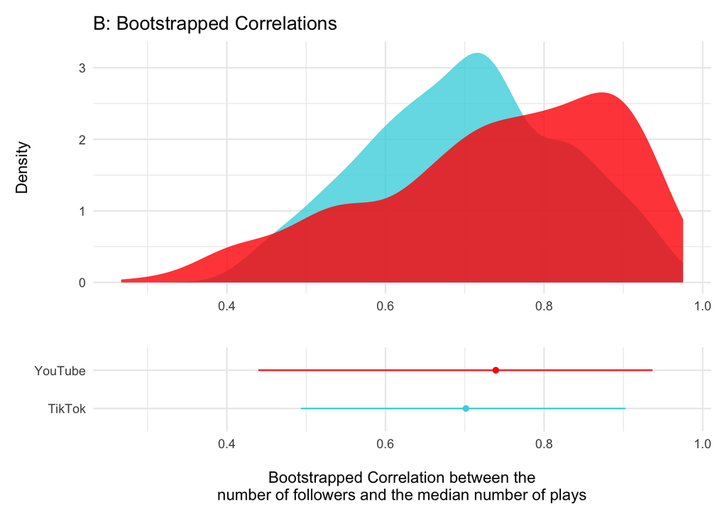

```r
bt_moment <- bt_h1 %>%
  drop_na(median_play, n_follower, Platform) %>%
  group_by(bt_index, Platform) %>%
  summarise(coef = cor(median_play, n_follower)) %>%
  group_by(Platform) %>%
  summarise(mean = mean(coef),
            lbound = quantile(coef, 5/100),
            hbound = quantile(coef, 95/100),
            min = min(coef),
            max = max(coef))

p1 <- bt_h1 %>%
  drop_na(median_play, n_follower, Platform) %>%
  group_by(bt_index, Platform) %>%
  summarise(coef = cor(median_play, n_follower)) %>%
  ggplot(aes(x = coef, fill = Platform)) +
  geom_density(color = NA, alpha = 0.8, show.legend = F) +
  scale_fill_manual(values = custom_colors) +
  theme_minimal() +
  labs(y = "Density", x = "", title = "B: Bootstrapped Correlations")

p2 <- bt_moment %>%
  ggplot(aes(x = Platform, color = Platform, y = mean, ymin = lbound, ymax = hbound)) +
  geom_point(show.legend = F) +
  geom_linerange(show.legend = F) +
  scale_color_manual(values = custom_colors) +
  coord_flip() +
  ylim(c(min(bt_moment$min), max(bt_moment$max))) +
  theme_minimal() +
  labs(y = "\nBootstrapped Correlation between the\nnumber of followers and the median number of plays", x = "")

h3_bt_cor_follower <- patchwork::wrap_plots(p1, p2, ncol = 1, heights = c(3, 1))
h3_bt_cor_follower
```

### Combined

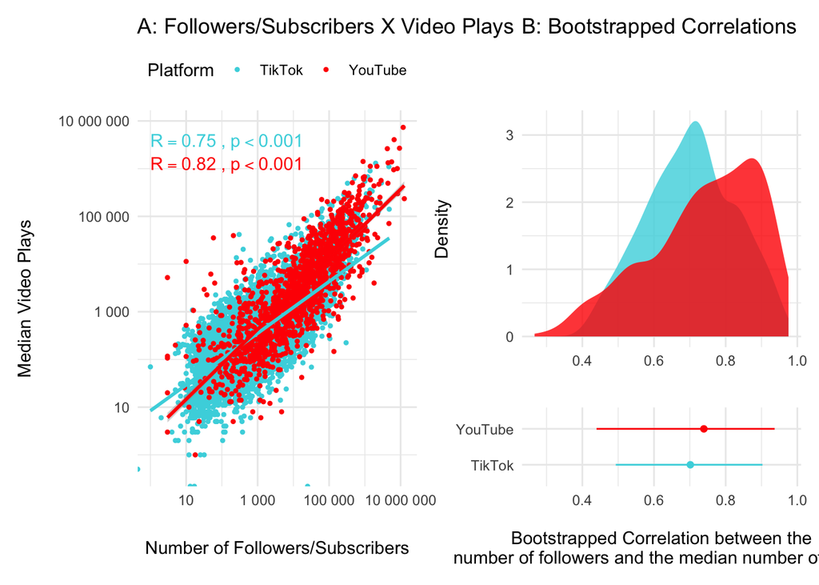

```r
patchwork::wrap_plots(h3_log, h3_bt_cor_follower, ncol = 2)
```

## Figure 5 - Peak-Median views ratio is higher on TikTok

The ratio of viewership for a single accounts’ most popular video to their median video viewership is higher on TikTok than on YouTube.

### Peak-median ratio

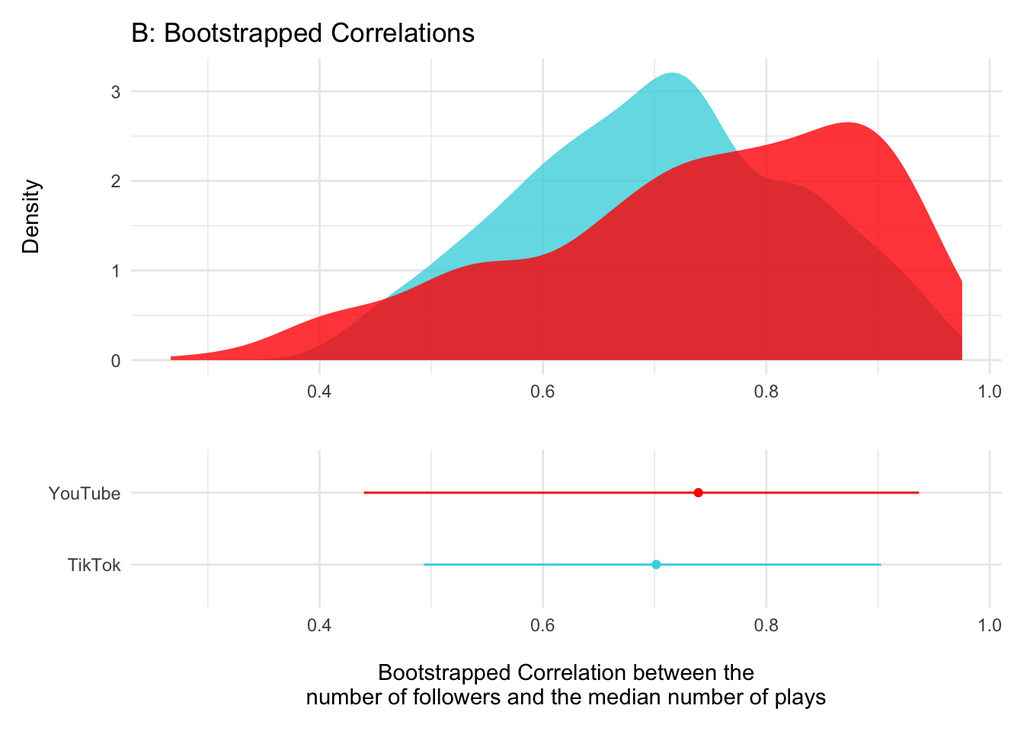

```r
gg_density <- dt_h1 %>%
  ggplot(aes(x = peak_median_ratio, fill = Platform)) +
  geom_density(color = NA, alpha = 0.8) +
  labs(x = "", y = "Density\n", title = "A: Peak-Median Plays Ratios") +
  theme_minimal() +
  scale_y_continuous(n.breaks = 3) +
  scale_x_log10(limits = c(1, 500000)) +
  theme(legend.position = "none") +
  scale_fill_manual(values = custom_colors)

median_labs <- dt_h1 %>%
  group_by(Platform) %>%
  summarize(peak_median_ratio = median(peak_median_ratio, na.rm = T) %>% round(2)) %>%
  mutate(peak_median_ratio_label = paste0("Median: ", peak_median_ratio))

w_results <- wilcox.test(log(peak_median_ratio+1) ~ Platform, data = dt_h1)

gg_boxplot <- dt_h1 %>%
  ggplot(aes(x= Platform, y = peak_median_ratio, fill = Platform)) +
  geom_boxplot() +
  coord_flip()  +
  labs(x = "Platform\n", y = "\nPeak-Median Plays Ratios") +
  theme_minimal() +
  theme(legend.position = "none") +
  geom_signif(comparisons = list(c("YouTube", "TikTok")),
              annotation=get_plabs(w_results$p.value))  +
  geom_text(data = median_labs,aes(label = peak_median_ratio_label), nudge_x = 0.3, nudge_y = 1.3) +
  scale_fill_manual(values = custom_colors) +
  scale_y_log10(limits = c(1, 500000))

h5_bt_peak_med_ratio_bt <- patchwork::wrap_plots(p1, p2, ncol = 1, heights = c(0.66, 0.33))
h5_bt_peak_med_ratio_bt
```

### Bootstrapped peak-median ratio

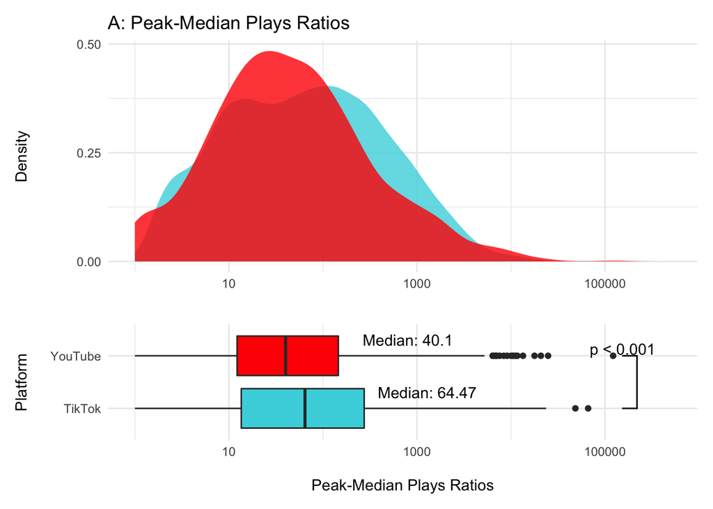

```r
bt_moment <- bt_h1 %>%
  drop_na(peak_median_ratio, Platform) %>%
  group_by(bt_index, Platform) %>%
  summarise(median = median(peak_median_ratio)) %>%
  group_by(Platform) %>%
  summarise(mean = mean(median),
            lbound = quantile(median, 5/100),
            hbound = quantile(median, 95/100),
            min = min(median),
            max = max(median))

p1 <- bt_h1 %>%
  drop_na(peak_median_ratio, Platform) %>%
  group_by(Platform, bt_index) %>%
  summarise(median = median(peak_median_ratio)) %>%
  ggplot(aes(x = median, fill = Platform)) +
  geom_density(color = NA, alpha = 0.8, show.legend = F) +
  scale_fill_manual(values = custom_colors) +
  xlim(c(min(bt_moment$min), max(bt_moment$max))) +
  theme_minimal() +
  labs(y = "", x = "", title = "B: Bootstrapped Median Ratios")

p2 <- bt_moment %>%
  ggplot(aes(x = Platform, color = Platform, y = mean, ymin = lbound, ymax = hbound)) +
  geom_point(show.legend = F) +
  geom_linerange(show.legend = F) +
  scale_color_manual(values = custom_colors) +
  coord_flip() +
  ylim(c(min(bt_moment$min), max(bt_moment$max))) +
  theme_minimal() +
  labs(y = "\nBootstrapped Median Peak-Median Plays Ratios", x = "")

h5_peak_median_ratio_logged <- wrap_plots(gg_density, gg_boxplot, nrow = 2, heights = c(0.66, 0.33))
h5_peak_median_ratio_logged
```

### Combined

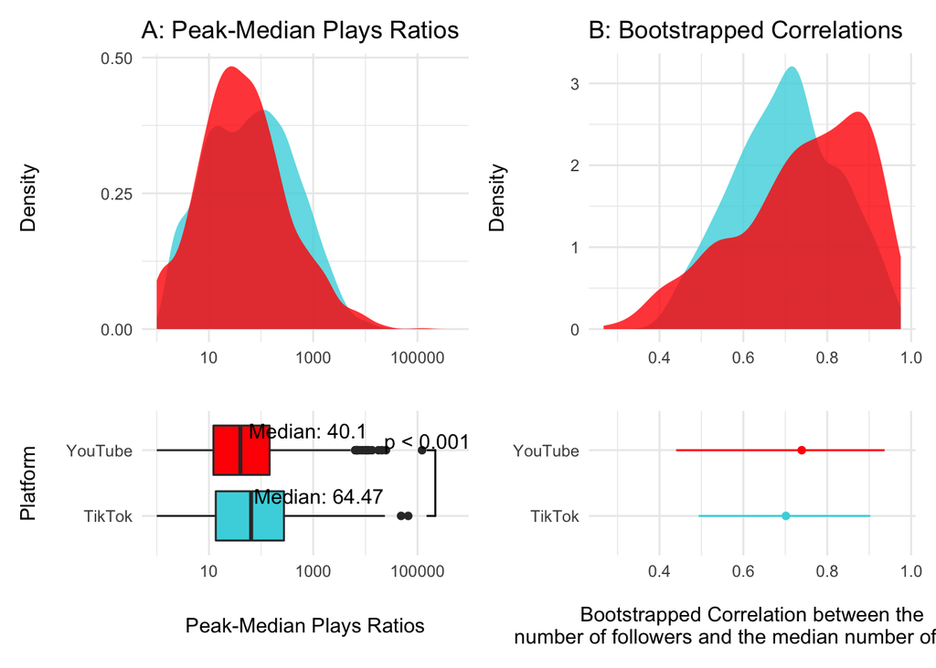

```r
patchwork::wrap_plots(h5_peak_median_ratio_logged, h5_bt_peak_med_ratio_bt, ncol = 2)
```

## Figure 6 - Distribution of video views per account shows a greater degree of inequality on TikTok

The gini coefficient for views per account is higher on TikTok than on YouTube.

### Gini coefficient of views per account

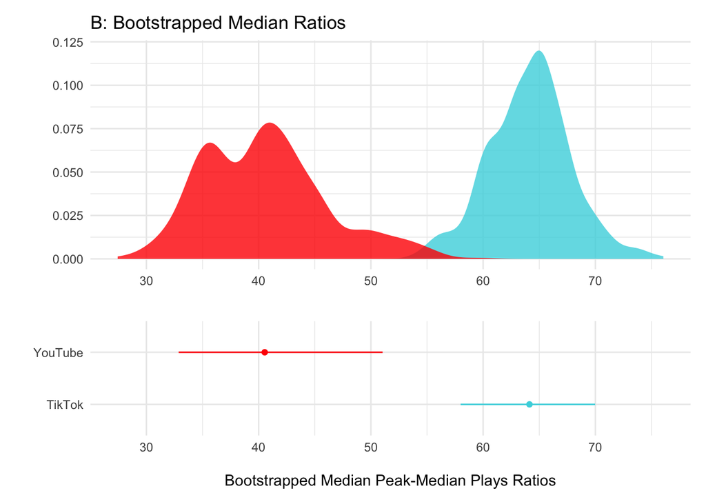

```r
gg_density <- dt_h1 %>%
  ggplot(aes(x = gini_views, fill = Platform)) +
  geom_density(color = NA, alpha = 0.8) +
  labs(x = "", y = "Density\n", title = "A: Gini Coefficients for Video Views per Account") +
  theme_minimal() +
  scale_y_continuous(n.breaks = 3) +
  theme(legend.position = "none") +
  scale_fill_manual(values = custom_colors)

w_results <- wilcox.test(gini_views ~ Platform, data = dt_h1)
median_labs <- dt_h1 %>%
  group_by(Platform) %>%
  summarize(gini_views = median(gini_views, na.rm = T) %>% round(2)) %>%
  mutate(gini_views_label = paste0("Median: ", gini_views))

gg_boxplot <- dt_h1 %>%
  ggplot(aes(x= Platform, y = gini_views, fill = Platform)) +
  geom_boxplot() +
  coord_flip()  +
  labs(x = "Platform\n", y = "\nGini Coefficient Views") +
  theme_minimal() +
  theme(legend.position = "none") +
  geom_signif(comparisons = list(c("YouTube", "TikTok")),
              annotation=get_plabs(w_results$p.value), vjust=-0.5)  +
  geom_text(data = median_labs,aes(label = gini_views_label), nudge_x = 0.3, nudge_y = -0.3) +
  scale_fill_manual(values = custom_colors)

h4_bt_gini <- patchwork::wrap_plots(p1, p2, ncol = 1, heights = c(0.66, 0.33))
h4_bt_gini
```

### Bootstrapped gini coefficient of views per account

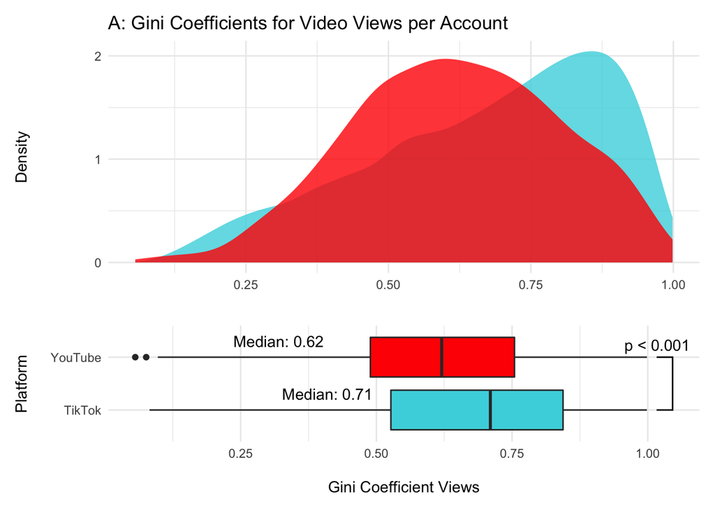

```r
bt_moment <- bt_h1 %>%
  drop_na(Platform, gini_views) %>%
  group_by(bt_index, Platform) %>%
  summarise(median = median(gini_views)) %>%
  group_by(Platform) %>%
  summarise(mean = mean(median),
            lbound = quantile(median, 5/100),
            hbound = quantile(median, 95/100),
            min = min(median),
            max = max(median))

p1 <- bt_h1 %>%
  drop_na(gini_views, Platform) %>%
  group_by(Platform, bt_index) %>%
  summarise(median = median(gini_views)) %>%
  ggplot(aes(x = median, fill = Platform)) +
  geom_density(color = NA, alpha = 0.8, show.legend = F) +
  scale_fill_manual(values = custom_colors) +
  xlim(c(min(bt_moment$min), max(bt_moment$max))) +
  theme_minimal() +
  labs(y = "", x = "", title = "B: Bootstrapped Median Gini Coefficients")

p2 <- bt_moment %>%
  ggplot(aes(x = Platform, color = Platform,
             y = mean, ymin = lbound, ymax = hbound)) +
  geom_point(show.legend = F) +
  geom_linerange(show.legend = F) +
  scale_color_manual(values = custom_colors) +
  coord_flip() +
  ylim(c(min(bt_moment$min), max(bt_moment$max))) +
  theme_minimal() +
  labs(y = "\nBootstrapped Median Gini Coefficient Views", x = "")

h4_gini <- wrap_plots(gg_density, gg_boxplot, nrow = 2, heights = c(0.66, 0.33))
h4_gini
```

### Combined

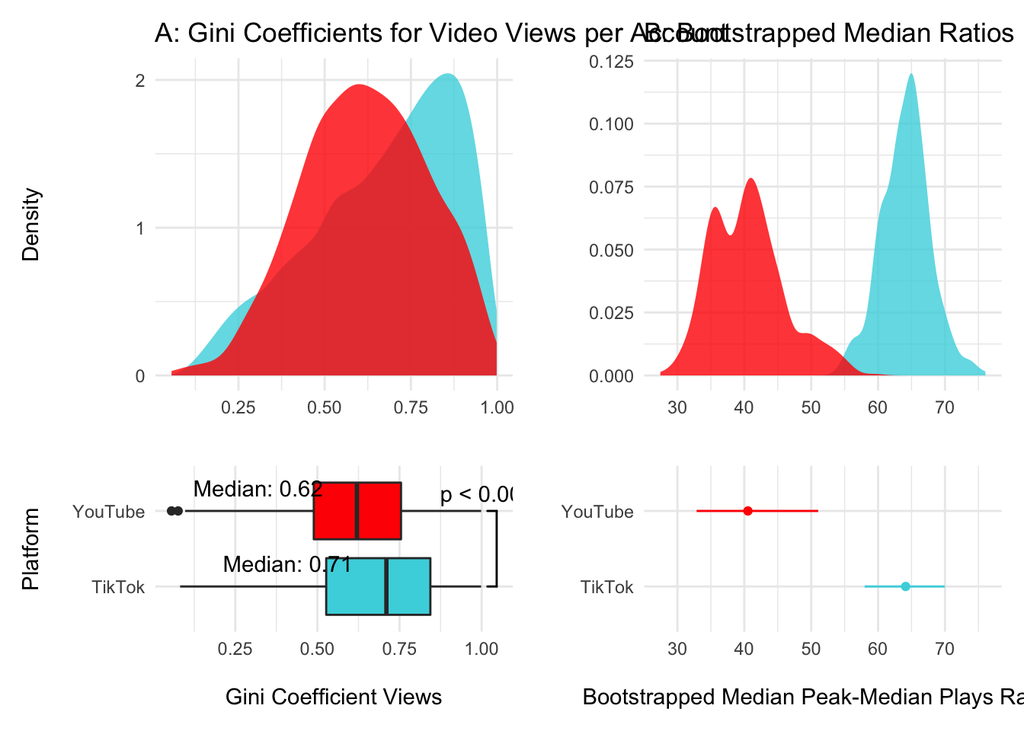

```r
patchwork::wrap_plots(h4_gini, h4_bt_gini, ncol = 2)
```